# HW 1

Rahul Sangole

4/14/2018

## Section 6.7

### 2. `plastics` dataset question

The dataset:

```r
plastics
```

```
##    Jan  Feb  Mar  Apr  May  Jun  Jul  Aug  Sep  Oct  Nov  Dec
## 1  742  697  776  898 1030 1107 1165 1216 1208 1131  971  783
## 2  741  700  774  932 1099 1223 1290 1349 1341 1296 1066  901
## 3  896  793  885 1055 1204 1326 1303 1436 1473 1453 1170 1023
## 4  951  861  938 1109 1274 1422 1486 1555 1604 1600 1403 1209
## 5 1030 1032 1126 1285 1468 1637 1611 1608 1528 1420 1119 1013
```

#### a. Plot the time series of sales of product A. Can you identify seasonal fluctuations and/or a trend?

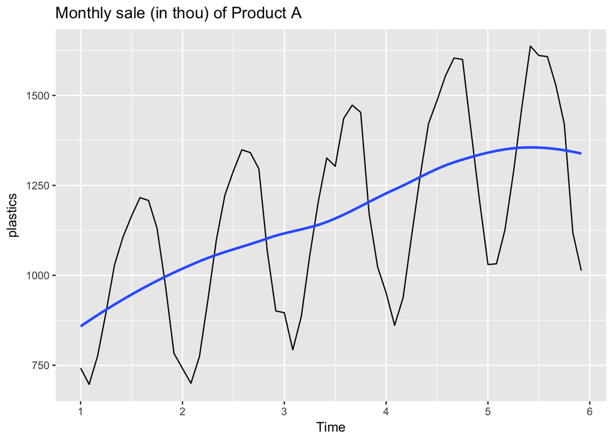

```r
ggplot2::autoplot(plastics, main ='Monthly sale (in thou) of Product A')+
    ggplot2::geom_smooth(se = F)
```

* Seasonal fluctuations exist, with peaks ~Aug-Sep and reduced sales at the year end * A monotonic near-linear trend also exists year over year

#### b. Use a classical multiplicative decomposition to calculate the trend-cycle and seasonal indices.

```r
multi_decomp <- decompose(plastics, type = 'multiplicative')
```

The trend and seasonal indices can be accessed via:

```r
multi_decomp$trend
```

```
##         Jan       Feb       Mar       Apr       May       Jun       Jul
## 1        NA        NA        NA        NA        NA        NA  976.9583
## 2 1000.4583 1011.2083 1022.2917 1034.7083 1045.5417 1054.4167 1065.7917
## 3 1117.3750 1121.5417 1130.6667 1142.7083 1153.5833 1163.0000 1170.3750
## 4 1208.7083 1221.2917 1231.7083 1243.2917 1259.1250 1276.5833 1287.6250
## 5 1374.7917 1382.2083 1381.2500 1370.5833 1351.2500 1331.2500        NA
##         Aug       Sep       Oct       Nov       Dec
## 1  977.0417  977.0833  978.4167  982.7083  990.4167
## 2 1076.1250 1084.6250 1094.3750 1103.8750 1112.5417
## 3 1175.5000 1180.5417 1185.0000 1190.1667 1197.0833
## 4 1298.0417 1313.0000 1328.1667 1343.5833 1360.6250
## 5        NA        NA        NA        NA        NA
```

```r
multi_decomp$seasonal
```

```
##         Jan       Feb       Mar       Apr       May       Jun       Jul
## 1 0.7670466 0.7103357 0.7765294 0.9103112 1.0447386 1.1570026 1.1636317
## 2 0.7670466 0.7103357 0.7765294 0.9103112 1.0447386 1.1570026 1.1636317
## 3 0.7670466 0.7103357 0.7765294 0.9103112 1.0447386 1.1570026 1.1636317
## 4 0.7670466 0.7103357 0.7765294 0.9103112 1.0447386 1.1570026 1.1636317
## 5 0.7670466 0.7103357 0.7765294 0.9103112 1.0447386 1.1570026 1.1636317
##         Aug       Sep       Oct       Nov       Dec
## 1 1.2252952 1.2313635 1.1887444 0.9919176 0.8330834
## 2 1.2252952 1.2313635 1.1887444 0.9919176 0.8330834
## 3 1.2252952 1.2313635 1.1887444 0.9919176 0.8330834
## 4 1.2252952 1.2313635 1.1887444 0.9919176 0.8330834
## 5 1.2252952 1.2313635 1.1887444 0.9919176 0.8330834
```

#### c. Do the results support the graphical interpretation from part (a)?

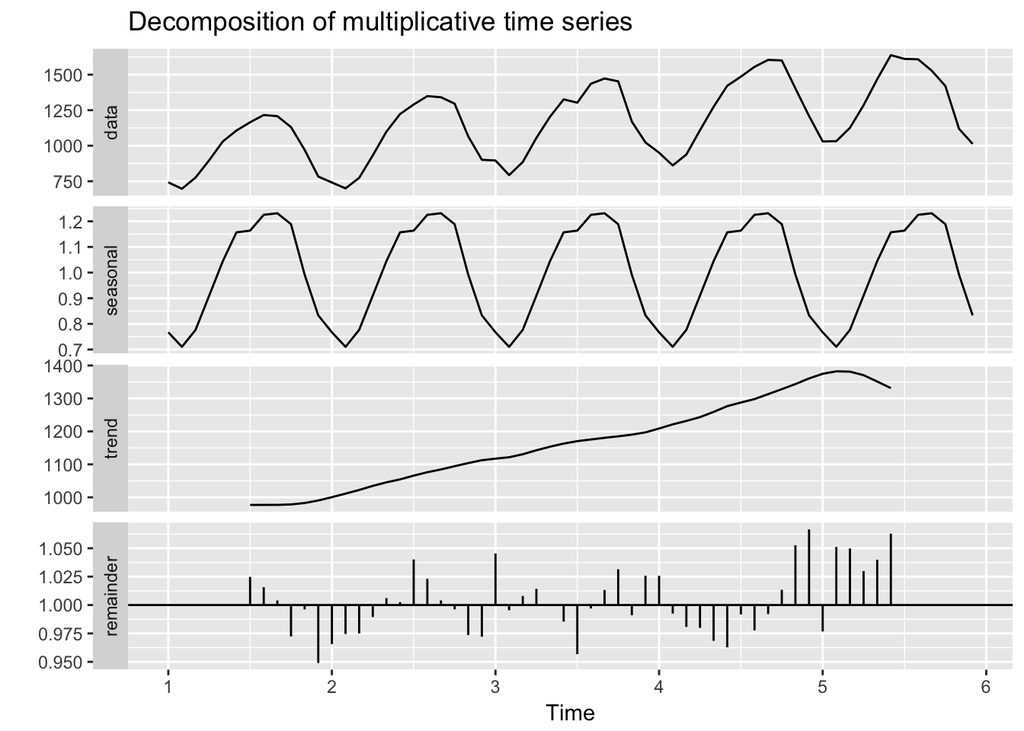

```r
ggplot2::autoplot(multi_decomp)
```

Yes

#### d. Compute and plot the seasonally adjusted data.

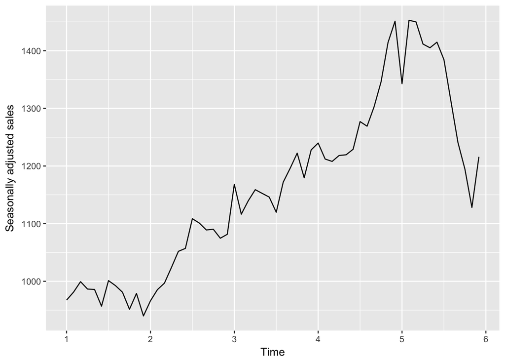

```r
ggplot2::autoplot(seasadj(multi_decomp), ylab='Seasonally adjusted sales')
```

#### e. Change one observation to be an outlier (e.g., add 500 to one observation), and recompute the seasonally adjusted data. What is the effect of the outlier?

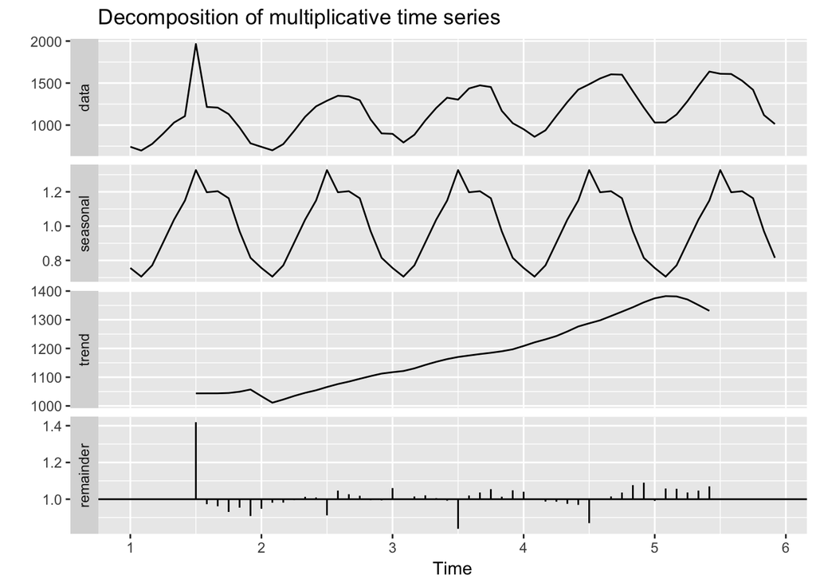

```r
plastics.withoutlier <- plastics
plastics.withoutlier[7] <- plastics.withoutlier[7] + 800
ggplot2::autoplot(decompose(plastics.withoutlier, type = 'multiplicative'))
```

* Classic decomposition is not robust to outliers. * It affects the seasonal contributions throughout the time series, since `decompose()` cannot adjust seasonal contributions over time. * As a result, we can see high residuals at (T+7) throughout the time series.

#### f. Does it make any difference if the outlier is near the end rather than in the middle of the time series?

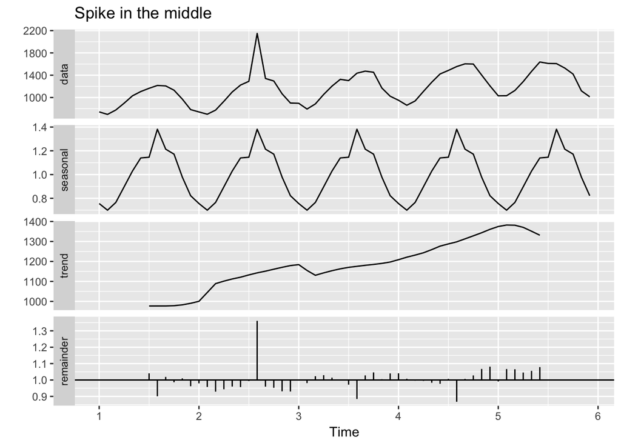

```r
plastics.withoutlier1 <- plastics
plastics.withoutlier1[20] <- plastics.withoutlier[20] + 800
plastics.withoutlier2 <- plastics
plastics.withoutlier2[59] <- plastics.withoutlier[59] + 800
ggplot2::autoplot(decompose(plastics.withoutlier1, type = 'multiplicative'))+labs(title='Spike in the middle')
```

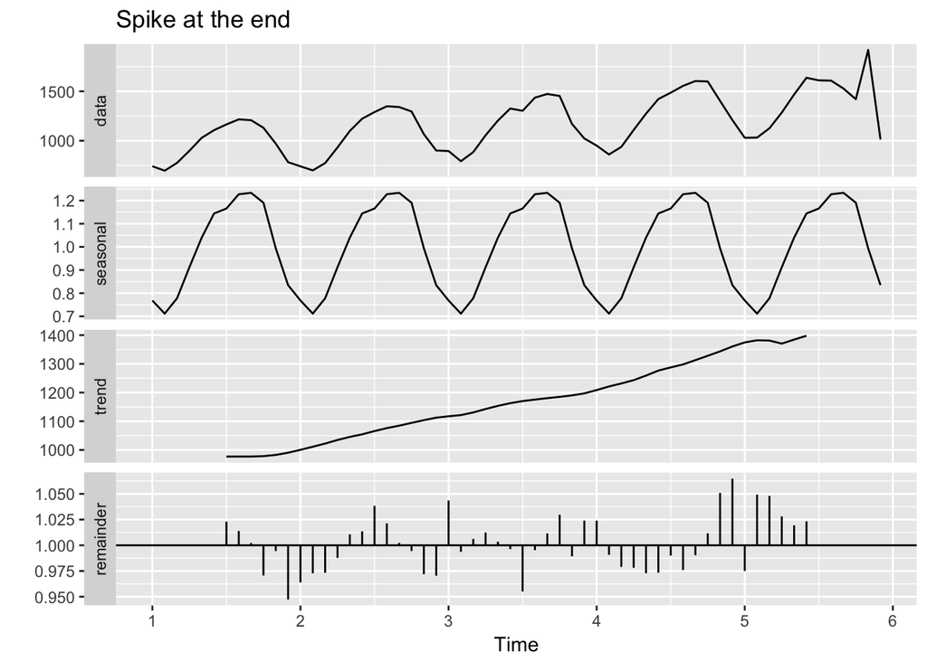

```r
ggplot2::autoplot(decompose(plastics.withoutlier2, type = 'multiplicative'))+labs(title='Spike at the end')
```

Yes.

The reason is that when the spike is at the end, if that portion of the signal is `NA` in the trend extraction using MA, it is not considered during calculation of the seasonal contributions.

#### g. Use a random walk with drift to produce forecasts of the seasonally adjusted data.

To extract the seasonally adjusted data:

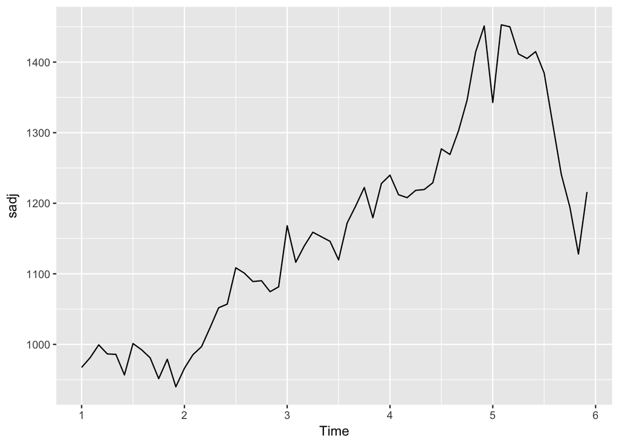

```r
sadj <- seasadj(multi_decomp)
ggplot2::autoplot(sadj)
```

Adding the random walk here, shown in red.

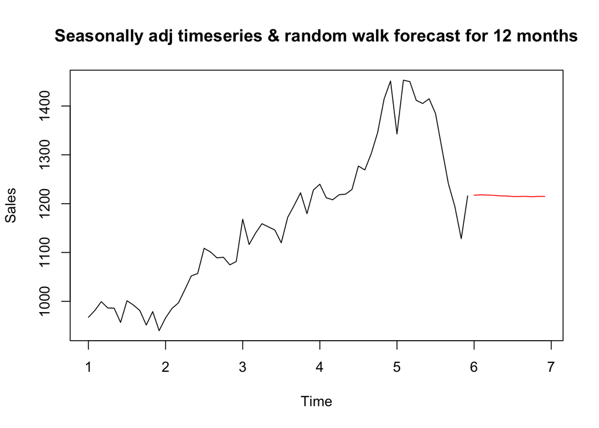

```r
h <-  12
mu <- tail(sadj, 1)
rwalk <- as.numeric(mu) + cumsum(rnorm(h,))
rwalk <- ts(rwalk, frequency = 12, start = c(6,1))
together <- ts.union(sadj, rwalk)
plot(together, main = 'Seasonally adj timeseries & random walk forecast for 12 months',plot.type = 's',col=c('black','red'), ylab = 'Sales')
```

#### h. Reseasonalize the results to give forecasts on the original scale.

Multiplying the seasonal component to the multiplicative series, we get results back in the original scale.

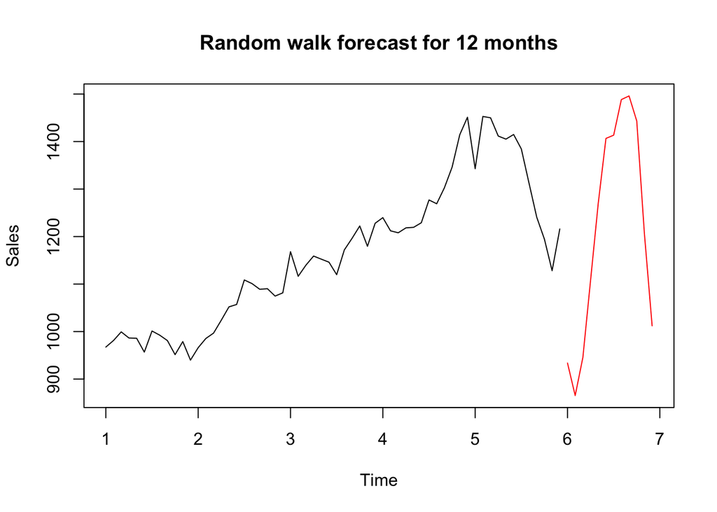

```r
rwalk_reseasoned <- rwalk * as.numeric(multi_decomp$seasonal)[1:12]
together <- ts.union(sadj, rwalk_reseasoned)
plot(together, main = 'Random walk forecast for 12 months',plot.type = 's',col=c('black','red'), ylab = 'Sales')
```